# Workshop: Introduction to R (for HPC users)

[figure not shown]

George G. Vega Yon  
University of Southern California  
Department of Preventive Medicine

USC Integrative Methods of Analysis for Genomic Epidemiology (IMAGE)  
Department of Preventive Medicine  
July 7th, 2018

# Agenda

1. Part 1: Talk about the basics: What is R? How to get help!?
2. Part 2: R language fundamentals.
3. Part 3: An extended example using HPCC

# PART 1

# Before we start

We will be using:

- R (of course), and you can get it from https://cloud.r-project.org/
- RStudio (highly recommended), an IDE for R, and you can get if from https://www.rstudio.com/products/rstudio/
- Materials for this presentation (including the presentation itself) can be downloaded from https://github.com/USCbiostats/intro2r-hcp-edition

# What is R

## The programming language

[figure not shown]

- Free software oriented for **statistical computing** and **graphics** (although people use for everything now a days)
- Is maintain mostly by the [**R Core Team**](https://www.r-project.org/contributors.html) (about 20 members worldwide), with the support of [**The R Foundation**](https://www.r-project.org/foundation/)
- Has a thriving community of users and developers worldwide:
  - Institutional support from: [**rOpenSci**](https://rOpenSci.org), [**R Consortium**](https://www.r-consortium.org), etc.
  - About **13,000 packages**(libraries) on [CRAN](https://cran.r-project.org) (The Comprehensive R Archive Network)
  - More than 1,000 attendees in useR!2017 conference

## A little bit of history

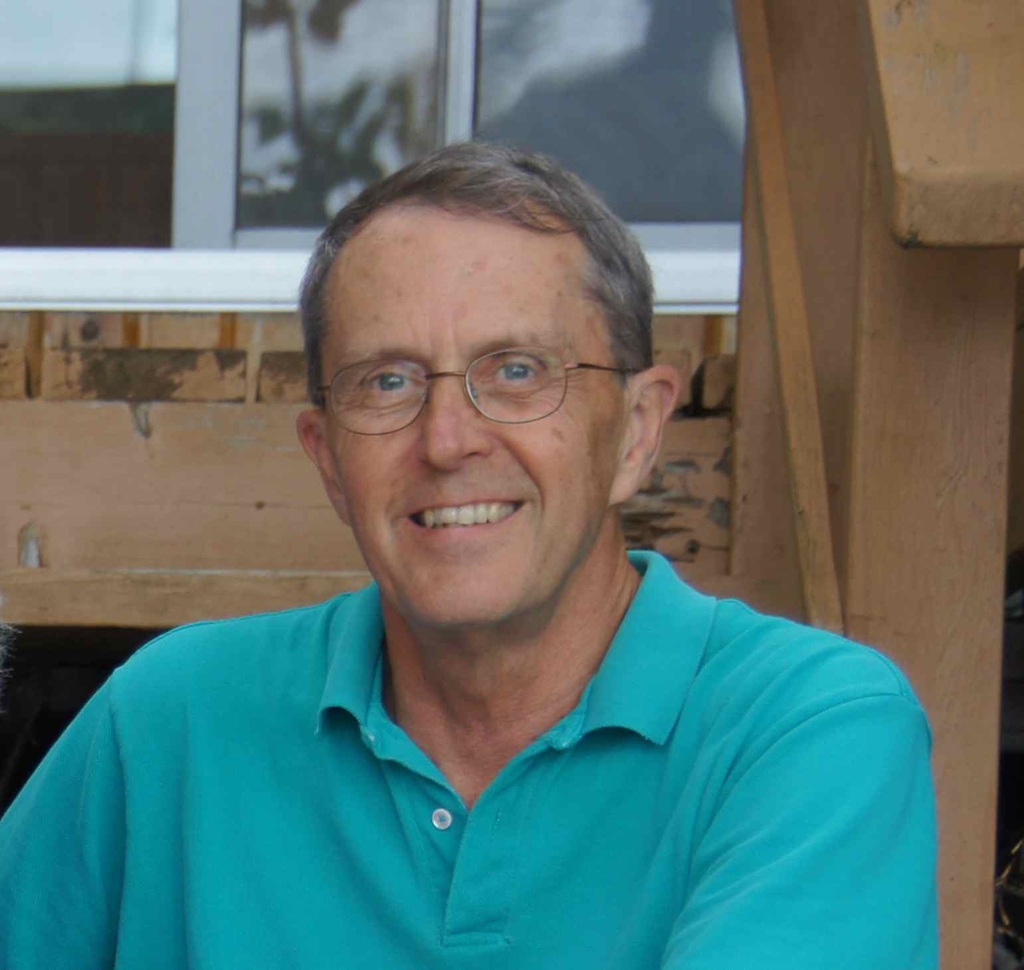

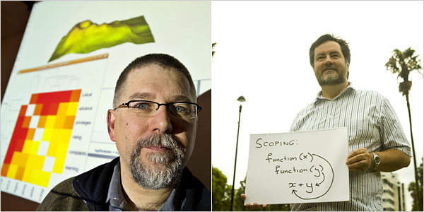

From left to right: John Chambers, Robert Gentleman, and Ross Ihaka.

- R (R Core Team 2018) is an implementation of the S (Statistics) programming language, which was created in 1976 by **John Chambers** while at Bell Labs.
- R itself was created by **[Ross Ihaka](https://wikipedia.org/wiki/Ross_Ihaka)** and **Robert Gentleman** at the University of Auckland, New Zealand. First release in 1995.
- Currently developed by the **[R Development Core Team](https://www.r-project.org/contributors.html)**, of which Chambers is a member.

(Source wiki)

# The first lesson: Getting help

## in R

In R, if you want to:

- Know about the `sqrt` function? `?sqrt`, or `help("sqrt")`
- Know about the `makeCluster` function in the R package `parallel`? `?parallel::makeCluster`, or `help("makeCluster", package="parallel")`
- Know about the Regular Expressions? `??"Regular Expressions"`, or `help.search("Regular Expressions")`
- See a full list of the functions and help files available in the package `boot`: `help(package="boot")`.
- Look at more in deph information about the Matrix package? `vignette(package="Matrix")`

## On the web

- Checkout the [CRAN Task Views](https://cran.r-project.org/web/views/)
- Take a look at the **rstats** tag on [StackOverflow.com](https://stackoverflow.com/questions/tagged/r)
- Visit the r-bloggers.com website
- Read one of the dozens of online free books about R created with the [R package bookdown](https://cran.r-project.org/package=bookdown) at [bookdown.org](https://bookdown.org/)
- Ask a question on twitter using the [#rstats](https://twitter.com/hashtag/rstats) hashtag.

## Books that I recommend

- The art of R programming https://nostarch.com/artofr.htm (Matloff 2011)
- Advanced R http://adv-r.had.co.nz/ (Wickham 2015)
- R Programming for Data Science https://bookdown.org/rdpeng/rprogdatascience/ (Peng 2012)
- R for Data Science http://r4ds.had.co.nz/ (Wickham and Grolemund 2016)
- Scientific Programming and Simulation using R (Jones, Maillardet, and Robinson 2009)

# The first lesson: Getting help (How to read it?)

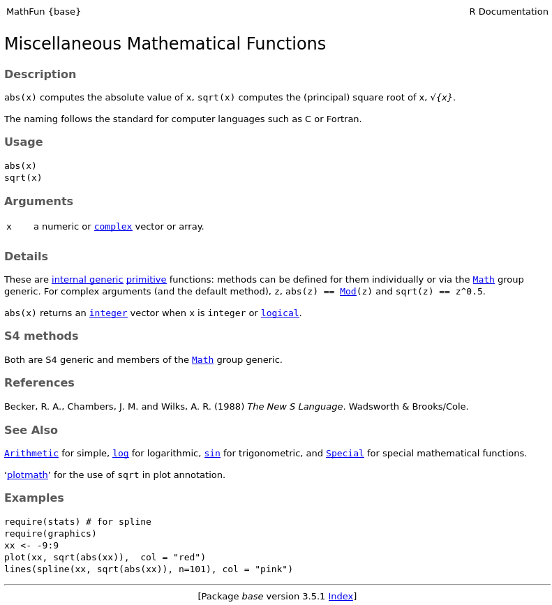

# The first lesson: Getting help (a mental model)

[figure not shown]

My own personal way of looking for R-based solutions to my problems (in science… of course)

# Questions

1. Using the `stats` package, How can you estimate a **generalized linear model** in R?
2. What is the command to **transpose** a matrix in R? What about the command for inverting a matrix?
3. Looking at CRAN task Views, what R packages are available for convex optimization? What about stochastic optimization?
4. Create a list of R packages that provide wrappers for working with Slurm.
5. What does return the function for fitting nonlinear least squares in the `stats` package?

# PART 2

# Creating objects

- In R you can create new objects by either using the assign operator (`<-`) or the equal sign `=`, for example, the following 2 are equivalent:

  ```r
  a <- 1
  a =  1
  ```

  And it works for any type of data

  ```r
  # Hey! here is a comment!.
  # Comments in R can be either at the begining of a line ...
  b <- "aloha" # ... or at the end of it!
  ```

  Historically the assign operator is the most common used.

# Data types

- The most basic data (object) type in R are vectors.

  ```r
  myvec1 <- vector("logical", 3)  # This is a logical vector of length 3
  myvec2 <- c(FALSE, TRUE, FALSE) # This is ALSO a logical vector of length 3
  myvec2
  ```

  ```
  ## [1] FALSE  TRUE FALSE
  ```

  ```r
  length(myvec2)
  ```

  ```
  ## [1] 3
  ```

- Vectors can be of different modes: `logical`, `integer`, `numeric` (double), `complex`, `character`, and `raw`. (so one mode per vector!).
- Vectors can also be lists, which is a VERY special type of object in R (most of its objects are lists!)

  ```r
  mylist1 <- vector("list", 2) # This is a list with 2 empty slots
  mylist2 <- list(NULL, NULL)  # This is ALSO a list with 2 empty slots
  mylist1
  ```

- Moreover, lists elements can have names

  ```r
  mylist2 <- list(first = NULL, second = 1, third = c("a", "b", "c"))
  mylist2
  ```

  ```
  ## $first
  ## NULL
  ##
  ## $second
  ## [1] 1
  ##
  ## $third
  ## [1] "a" "b" "c"
  ```

  And we can access them as follows

  ```r
  # Getting the 3rd element of the list
  mylist2$third      # By name using the dollar sign
  mylist2[[3]]       # By position
  mylist2[["third"]] # By name using a string
  ```

  ```
  ## [1] "a" "b" "c"
  ```

# Attributes and Structure

- Objects in R have attributes (metadata)

  ```r
  # Here are the attributes of the iris dataset
  attributes(iris)
  ```

  ```
  ## $names
  ## [1] "Sepal.Length" "Sepal.Width"  "Petal.Length" "Petal.Width"
  ## [5] "Species"
  ##
  ## $row.names
  ##   [1]   1   2   3   4   5   6   7   8   9  10  11  12  13  14  15  16  17
  ##  [18]  18  19  20  21  22  23  24  25  26  27  28  29  30  31  32  33  34
  ##  [35]  35  36  37  38  39  40  41  42  43  44  45  46  47  48  49  50  51
  ##  [52]  52  53  54  55  56  57  58  59  60  61  62  63  64  65  66  67  68
  ##  [69]  69  70  71  72  73  74  75  76  77  78  79  80  81  82  83  84  85
  ##  [86]  86  87  88  89  90  91  92  93  94  95  96  97  98  99 100 101 102
  ## [103] 103 104 105 106 107 108 109 110 111 112 113 114 115 116 117 118 119
  ## [120] 120 121 122 123 124 125 126 127 128 129 130 131 132 133 134 135 136
  ## [137] 137 138 139 140 141 142 143 144 145 146 147 148 149 150
  ##
  ## $class
  ## [1] "data.frame"
  ```

  ```r
  head(iris)
  ```

  ```
  ##   Sepal.Length Sepal.Width Petal.Length Petal.Width Species
  ## 1          5.1         3.5          1.4         0.2  setosa
  ## 2          4.9         3.0          1.4         0.2  setosa
  ## 3          4.7         3.2          1.3         0.2  setosa
  ## 4          4.6         3.1          1.5         0.2  setosa
  ## 5          5.0         3.6          1.4         0.2  setosa
  ## 6          5.4         3.9          1.7         0.4  setosa
  ```

- You can take a general look at the structure of an R object with the `str()` function

  ```r
  # Let's take a look at the iris dataset, again
  str(iris)
  ```

  ```
  ## 'data.frame':    150 obs. of  5 variables:
  ##  $ Sepal.Length: num  5.1 4.9 4.7 4.6 5 5.4 4.6 5 4.4 4.9 ...
  ##  $ Sepal.Width : num  3.5 3 3.2 3.1 3.6 3.9 3.4 3.4 2.9 3.1 ...
  ##  $ Petal.Length: num  1.4 1.4 1.3 1.5 1.4 1.7 1.4 1.5 1.4 1.5 ...
  ##  $ Petal.Width : num  0.2 0.2 0.2 0.2 0.2 0.4 0.3 0.2 0.2 0.1 ...
  ##  $ Species     : Factor w/ 3 levels "setosa","versicolor",..: 1 1 1 1 1 1 1 1 1 1 ...
  ```

# Missing values

R has different types of Missing values:

- `NA`: no information, has length 1,
- `NULL`: which has length 0,
- `Inf`: Infinite, and
- `NaN`: Not a Number

```r
str(c(NA, 1L))        # Integers can have NAs
##  int [1:2] NA 1
str(c(NaN, 1L, Inf))  # But not NaN or Inf (automatic coercion)
##  num [1:3] NaN 1 Inf
str(c(-Inf, 1, NULL, +Inf)) # And Nulls are... of length 0!
##  num [1:3] -Inf 1 Inf
```

- In the second line, we have an example of *automatic coercion*
- These have companion functions `is.na()`, `is.null`, `is.infinite` (or `is.finite()`, which covers NA, Inf, and NaN), and `is.nan`.

# Questions

1. What is the mode of the following vector `myvector <- c(NA, NaN, Inf)`? (try not to use the `mode()` function in R)
2. The `c()` function can be used with other vectors, for example

   ```r
   my_integer_vector <- c(1L, 2L, 3L)
   my_string_vector  <- c("hello", "world")
   ```

   What is the mode of the vector `c(my_integer_vector, my_string_vector)`?
3. What do each one of these functions return on the vector `myvector`?
4. What are the attributes of the following object `mymat <- matrix(runif(12), ncol=4)`?

# Linear Algebra

- **Matrix**: A special class of array, are vectors with a `dim` attribute of length 2 (number of rows and number of columns).

  ```r
  mymat <- matrix(1:9, ncol=3) # A matrix with numbers 1 through 9 with 3 columns
  mymat
  ```

  ```
  ##      [,1] [,2] [,3]
  ## [1,]    1    4    7
  ## [2,]    2    5    8
  ## [3,]    3    6    9
  ```

  ```r
  str(mymat)
  ```

  ```
  ##  int [1:3, 1:3] 1 2 3 4 5 6 7 8 9
  ```

  R stores elements in column major-order. We can access matrices elements in the following way.

  ```r
  mymat[1, 2] # The element in the (1, 2) location of the matrix
  ## [1] 4
  mymat[4]    # The fourth element in the vector... which is (1, 2)
  ## [1] 4
  ```

  Matrices can have row and column names too.
- Some matrix fundamental operators, for matrices `A`, and `B` (both square) with the same dimensions (just for the examples):
  - Element wise product, addition, substraction, and quotient: `A * B`, `A + B`, `A - B`, `A/B`
  - Transpose `t(A)`
  - Inverse `solve(A)`
  - Column and row bind, `cbind(A, B)`, `rbind(A, B)`

  See the `help("%*%")`, `help("cbind")`

# Questions

- Given the following matrices `A`, `B`, and C

  ```r
  set.seed(122)
  A <- matrix(rnorm(12), ncol=3)
  B <- matrix(rnorm(12), nrow=3)
  C <- A %*% cbind(1:3) + rnorm(4) # Adding a vector of length 4!
  ```

  Compute
  1. Matrix multiplication
  2. Transpose of A
  3. Element-wise product of A and B’
  4. The inverse of the cross product of A
  5. $(A^\mbox{t} A)^{-1} A^\mbox{t} C$

# Other fundamental types

Other fundamental type of objects in R are:

- **Factors**: A set of *integer codes* with labels (levels).

  ```r
  myfactor <- factor(c("a", "a", "b", "xyz"))
  myfactor
  ```

  ```
  ## [1] a   a   b   xyz
  ## Levels: a b xyz
  ```

  We treat factors as vectors.
- **Data frames**: “A data frame is a list of variables of the same number of rows with unique row names, given class”data.frame“.”

  ```r
  # Data frames can have multiple type objects, here, factor and numeric
  mydf <- data.frame(a_letter = c("a", "b", "c"), a_number = c(1, 2, 100))
  mydf
  ```

  ```
  ##   a_letter a_number
  ## 1        a        1
  ## 2        b        2
  ## 3        c      100
  ```

  ```r
  str(mydf)
  ```

  ```
  ## 'data.frame':    3 obs. of  2 variables:
  ##  $ a_letter: Factor w/ 3 levels "a","b","c": 1 2 3
  ##  $ a_number: num  1 2 100
  ```

  We can access data frame objects as follow

  ```r
  mydf$a_letter      # Dollar sign
  mydf[[1]]          # Position of the column
  mydf[["a_letter"]] # Name of the column
  ```

  ```
  ## [1] a b c
  ## Levels: a b c
  ```

# Statistical Functions

- R has a very nice set of families of distributions. In general, distribution functions have the following name structure:
  1. **Random Number Generation**: `r[name-of-the-distribution]`, e.g. `rnorm` for normal, `runif` for uniform.
  2. **Density function**: `d[name-of-the-distribution]`, e.g. `dnorm` for normal, `dunif` for uniform.
  3. **Cumulative Distribution Function (CDF)**: `p[name-of-the-distribution]`, e.g. `pnorm` for normal, `punif` for uniform.
  4. **Inverse of the CDF (quantile)**: `q[name-of-the-distribution]`, e.g. `qnorm` for the normal, `qunif` for the uniform.
- In the case of [**pseudo random numbers**](https://en.wikipedia.org/wiki/Pseudorandom_number_generator) (the `r` prefix), it is important to **always** set the seed to ensure **reproducibility**

  ```r
  # First run
  set.seed(12)
  rnorm(4)
  ## [1] -1.4805676  1.5771695 -0.9567445 -0.9200052

  # Second run
  set.seed(12)
  rnorm(4)
  ## [1] -1.4805676  1.5771695 -0.9567445 -0.9200052
  ```

  More distributions available at `??Distributions`.
- Take a look at the normal distribution

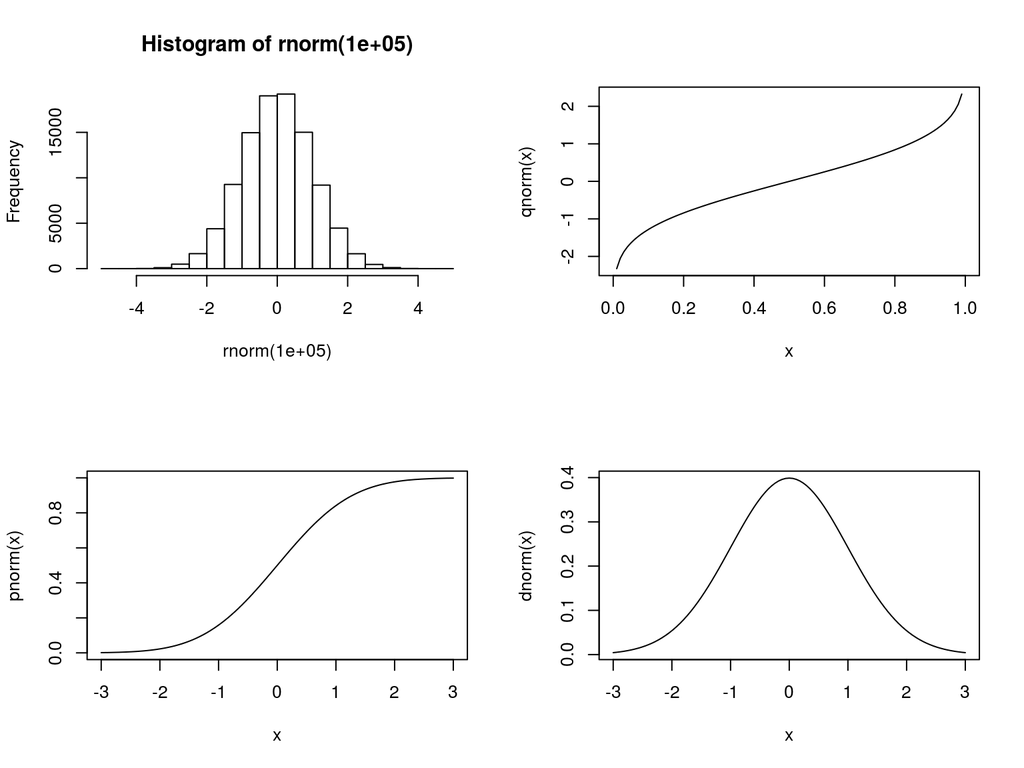

```r
set.seed(12)
op <- par(mfrow = c(2,2))
hist(rnorm(1e5))
curve(qnorm)
curve(pnorm, xlim=c(-3, 3))
curve(dnorm, xlim=c(-3, 3))
```

```r
par(op)
```

- Take a look at the exponential

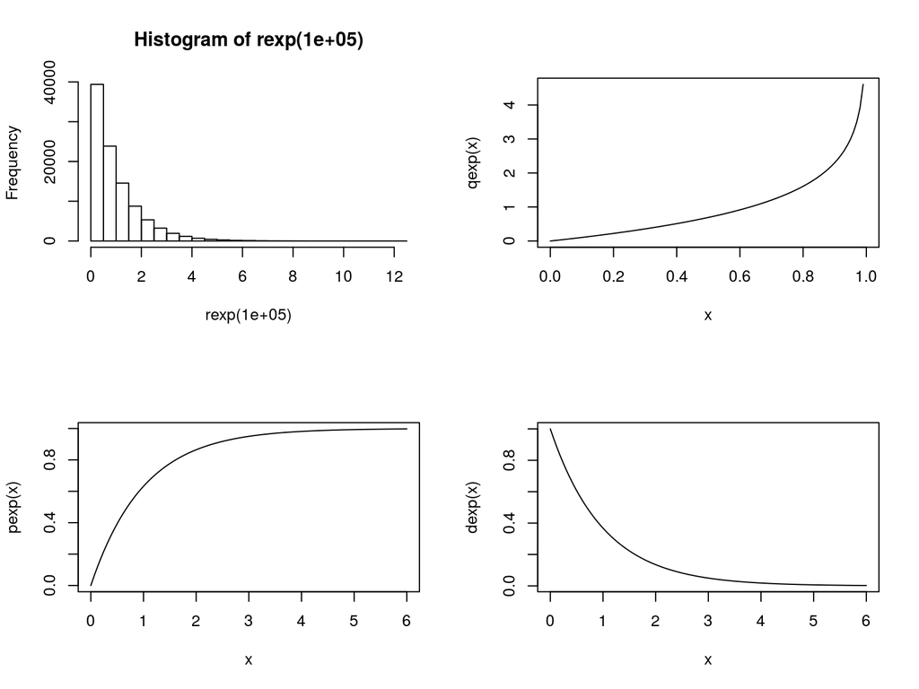

```r
set.seed(12)
op <- par(mfrow = c(2,2))
hist(rexp(1e5))
curve(qexp)
curve(pexp, xlim=c(0, 6))
curve(dexp, xlim=c(0, 6))
```

```r
par(op)
```

# Questions

1. Draw 1e5 samples from a chi2 with 2 degrees of freedom (hint: check `?Distributions`).
2. Draw 1e5 samples from a chi2 with 2 degrees of freedom using `rnorm` (hint: Recall that if $X\sim N(0,1)$, then $X^2\sim\chi^2_1$, and if $X, Y\sim N(0,1)$, then $X^2 + Y^2\sim\chi^2_2$).

# Control-flow statements

- For-loops

  ```r
  # The oldfashion forloop
  for (i in 1:10) {
    print(paste("I'm step", i, "/", 10))
  }
  ```

  ```
  ## [1] "I'm step 1 / 10"
  ## [1] "I'm step 2 / 10"
  ## [1] "I'm step 3 / 10"
  ## [1] "I'm step 4 / 10"
  ## [1] "I'm step 5 / 10"
  ## [1] "I'm step 6 / 10"
  ## [1] "I'm step 7 / 10"
  ## [1] "I'm step 8 / 10"
  ## [1] "I'm step 9 / 10"
  ## [1] "I'm step 10 / 10"
  ```

- Ifelse

  ```r
  # A nice ifelse
  for (i in 1:10) {

    if (i %% 2) # Modulus operand
      print(paste("I'm step", i, "/", 10, "(and I'm odd)"))
    else
      print(paste("I'm step", i, "/", 10, "(and I'm even)"))

  }
  ```

  ```
  ## [1] "I'm step 1 / 10 (and I'm odd)"
  ## [1] "I'm step 2 / 10 (and I'm even)"
  ## [1] "I'm step 3 / 10 (and I'm odd)"
  ## [1] "I'm step 4 / 10 (and I'm even)"
  ## [1] "I'm step 5 / 10 (and I'm odd)"
  ## [1] "I'm step 6 / 10 (and I'm even)"
  ## [1] "I'm step 7 / 10 (and I'm odd)"
  ## [1] "I'm step 8 / 10 (and I'm even)"
  ## [1] "I'm step 9 / 10 (and I'm odd)"
  ## [1] "I'm step 10 / 10 (and I'm even)"
  ```

- While

  ```r
  # A while
  i <- 10
  while (i > 0) {
    print(paste("I'm step", i, "/", 10))
    i <- i - 1
  }
  ```

  ```
  ## [1] "I'm step 10 / 10"
  ## [1] "I'm step 9 / 10"
  ## [1] "I'm step 8 / 10"
  ## [1] "I'm step 7 / 10"
  ## [1] "I'm step 6 / 10"
  ## [1] "I'm step 5 / 10"
  ## [1] "I'm step 4 / 10"
  ## [1] "I'm step 3 / 10"
  ## [1] "I'm step 2 / 10"
  ## [1] "I'm step 1 / 10"
  ```

# Functions

- Understanding functions, and functional programming can be very useful for your day-to-day work with R (and any programming language).
- Functions can be created in a single line, or span multiple lines of code.
- Usually, functions are structured as follow:

  ```r
  name_of_the_function <- function(
    argument1,    # First argument, required value
    argument2 = 1 # Second argument, has a default (so is optional)
  ) {

    [your neat R code here]

    return(answer)

  }
  ```

- This is the very basic that we can write in R

  ```r
  # A function that does nothing
  my_lame_function <- function() {}
  my_lame_function()
  ```

- Here is a more complicated function

  ```r
  calc_sum <- function(A, B) {
    A + B
  }

  calc_sum(1, 5)
  ```

  ```
  ## [1] 6
  ```

- We can use recursions too!

  ```r
  # An inefficient implementation of the Fibonacci number
  fib <- function(i) {

    if (i <= 2)
      return(1)

    fib(i - 2) + fib(i - 1)

  }

  c(fib(1), fib(2), fib(4), fib(5), fib(6), fib(7), fib(8))
  ```

  ```
  ## [1]  1  1  3  5  8 13 21
  ```

# PART 3

# Agenda

1. High-Performance Computing: An overview
2. Parallel computing in R
3. Extended examples

# High-Performance Computing: An overview

Loosely, from R’s perspective, we can think of HPC in terms of two, maybe three things:

1. Big data: How to work with data that doesn’t fit your computer
2. Parallel computing: How to take advantage of multiple core systems
3. Compiled code: Write your own low-level code (if R doesn’t has it yet…)

(Checkout [CRAN Task View on HPC](https://cran.r-project.org/web/views/HighPerformanceComputing.html))

# Big Data

- Buy a bigger computer/RAM memory (not the best solution!)
- Use out-of-memory storage, i.e., don’t load all your data in the RAM. e.g. The bigmemory, data.table, HadoopStreaming R packages
- Store it more efficiently, e.g.: Sparse Matrices (take a look at the `dgCMatrix` objects from the Matrix R package)

# Parallel computing

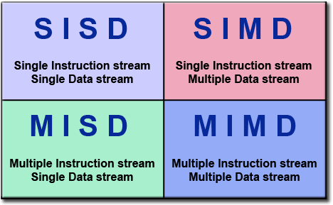

Flynn’s Classical Taxonomy ([Introduction to Parallel Computing, Blaise Barney, Lawrence Livermore National Laboratory](https://computing.llnl.gov/tutorials/parallel_comp/#Whatis))

# GPU vs CPU

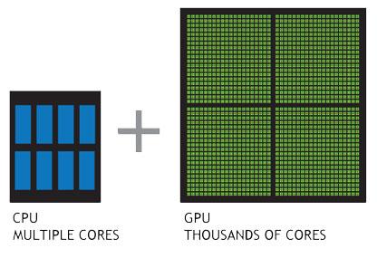

[NVIDIA Blog](http://www.nvidia.com/object/what-is-gpu-computing.html)

- **Why are we still using CPUs instead of GPUs?**

  > GPUs have far more processor cores than CPUs, but because each GPU core runs significantly slower than a CPU core and do not have the features needed for modern operating systems, they are not appropriate for performing most of the processing in everyday computing. They are most suited to compute-intensive operations such as video processing and physics simulations. ([bwDraco at superuser](https://superuser.com/questions/308771/why-are-we-still-using-cpus-instead-of-gpus))
- Why use OpenMP if GPU is *suited to compute-intensive operations*? Well, mostly because OpenMP is **VERY** easy to implement (easier than CUDA, which is the easiest way to use GPU).

# When is it a good idea?

[figure not shown]

Ask yourself these questions before jumping into HPC!

# Parallel computing in R

While there are several alternatives (just take a look at the [High-Performance Computing Task View](https://cran.r-project.org/web/views/HighPerformanceComputing.html)), we’ll focus on the following R-packages for explicit parallelism:

- **parallel**: R package that provides ‘[s]upport for parallel computation, including random-number generation’.
- **rslurm**: ‘Send long-running or parallel jobs to a Slurm workload manager (i.e. cluster) using the slurm_call or slurm_apply functions.’

Implicit parallelism, on the other hand, are out-of-the-box tools that allow the programmer not to worry about parallelization, e.g. such as [**gpuR**](https://cran.r-project.org/package=gpuR) for Matrix manipulation using GPU.

# Parallel workflow

# parallel example 1: Parallel RNG

```r
# 1. CREATING A CLUSTER
library(parallel)
cl <- makePSOCKcluster(2)

# 2. PREPARING THE CLUSTER
clusterSetRNGStream(cl, 123) # Equivalent to `set.seed(123)`

# 3. DO YOUR CALL
ans <- parSapply(cl, 1:2, function(x) runif(1e3))
(ans0 <- var(ans))
```

```
#               [,1]          [,2]
# [1,]  0.0861888293 -0.0001633431
# [2,] -0.0001633431  0.0853841838
```

```r
# I want to get the same!
clusterSetRNGStream(cl, 123)
ans1 <- var(parSapply(cl, 1:2, function(x) runif(1e3)))

all.equal(ans0, ans1) # All equal!
```

```
# [1] TRUE
```

```r
# 4. STOP THE CLUSTER
stopCluster(cl)
```

# parallel example 1: Parallel RNG (cont.)

In the case of `makeForkCluster`

```r
# 1. CREATING A CLUSTER
library(parallel)

# The fork cluster will copy the -nsims- object
nsims <- 1e3
cl    <- makeForkCluster(2)

# 2. PREPARING THE CLUSTER
RNGkind("L'Ecuyer-CMRG")
set.seed(123)

# 3. DO YOUR CALL
ans <- do.call(cbind, mclapply(1:2, function(x) {
  runif(nsims) # Look! we use the nsims object!
               # This would have fail in makePSOCKCluster
               # if we didn't copy -nsims- first.
  }))
(ans0 <- var(ans))

# Same sequence with same seed
set.seed(123)
ans1 <- var(do.call(cbind, mclapply(1:2, function(x) runif(nsims))))

ans0 - ans1 # A matrix of zeros

# 4. STOP THE CLUSTER
stopCluster(cl)
```

# parallel example 2: Simulating $\pi$

- We know that $\pi = \frac{A}{r^2}$. We approximate it by randomly adding points $x$ to a square of size 2 centered at the origin.
- So, we approximate $\pi$ as $\Pr\{\|x\| \leq 1\}\times 2^2$

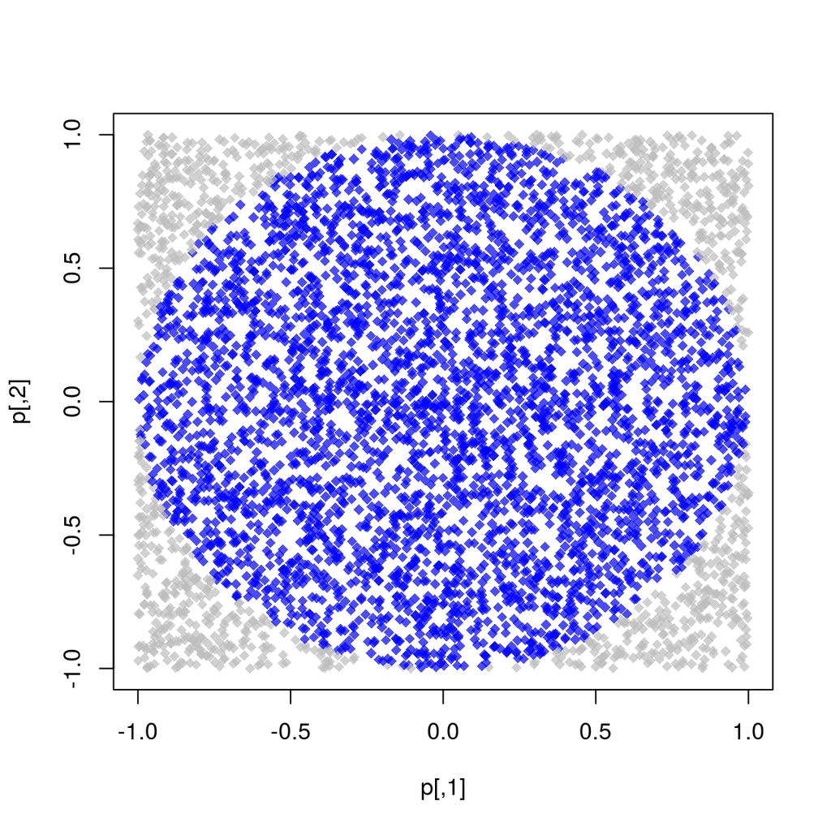

The R code to do this

```r
pisim <- function(i, nsim) {  # Notice we don't use the -i-
  # Random points
  ans  <- matrix(runif(nsim*2), ncol=2)

  # Distance to the origin
  ans  <- sqrt(rowSums(ans^2))

  # Estimated pi
  (sum(ans <= 1)*4)/nsim
}
```

# parallel example 2: Simulating $\pi$ (cont.)

```r
# Setup
cl <- makePSOCKcluster(10)
clusterSetRNGStream(cl, 123)

# Number of simulations we want each time to run
nsim <- 1e5

# We need to make -nsim- and -pisim- available to the
# cluster
clusterExport(cl, c("nsim", "pisim"))

# Benchmarking: parSapply and sapply will run this simulation
# a hundred times each, so at the end we have 1e5*100 points
# to approximate pi
rbenchmark::benchmark(
  parallel = parSapply(cl, 1:100, pisim, nsim=nsim),
  serial   = sapply(1:100, pisim, nsim=nsim), replications = 1
)[,1:4]
```

```
#       test replications elapsed relative
# 1 parallel            1   0.650    1.000
# 2   serial            1   1.166    1.794
```

```r
ans_par <- parSapply(cl, 1:100, pisim, nsim=nsim)
ans_ser <- sapply(1:100, pisim, nsim=nsim)
stopCluster(cl)
```

```
#      par      ser        R
# 3.141561 3.141677 3.141593
```

# Slurm Example 1

```r
# Include this to tell where everything will be living at
.libPaths("~/R/x86_64-pc-linux-gnu-library/3.4/")

# Default CRAN mirror from where to download R packages
options(repos =c(CRAN="https://cloud.r-project.org/"))

library(ABCoptim)

fun <- function(x) {
  -cos(x[1])*cos(x[2])*exp(-((x[1] - pi)^2 + (x[2] - pi)^2))
}

ans <- abc_optim(rep(0,2), fun, lb=-10, ub=10, criter=50)

saveRDS(
   ans,
   file = paste0(
      "~/hpc-with-r/examples/01-slurm-abcoptim-",
      Sys.getenv("SLURM_JOB_ID"),
      "-",
      Sys.getenv("SLURM_ARRAY_TASK_ID"),
      ".rds"
))
```

```bash
#!/bin/bash
#SBATCH --tasks=1
#SBATCH --array=1-3
#SBATCH --job-name=01-slurm-abcoptim
#SBATCH --output=01-slurm-abcoptim-%A_%a.out

source /usr/usc/R/3.4.0/setup.sh
Rscript --vanilla ~/hpc-with-r/examples/01-slurm-abcoptim.R
```

# RcppArmadillo + OpenMP + Slurm: Using the `rslurm` package

- The [`rslurm` package (Marchand, 2017)](https://CRAN.R-project.org/package=rslurm) provides a wrapper of Slurm in R.
- Without the need of knowing much about the syntax of `slurm`, this R package does the following:
  1. Writes an R source file that sets up each node with your current config (packages, libpath, etc.). The outputs are stored in a known folder so these can be fetched out later.
  2. Writes a bash file with the call to `sbatch` (you can specify options).
  3. Executes the bash file and returns the jobid (you can query its status interatively).

     ```r
     library(rslurm)

     # How many nodes are we going to be using
     nnodes <- 2L

     # The slurm_apply function is what makes all the work
     sjob <- slurm_apply(
       # We first define the job as a function
       f = function(n) {

         # Compiling Rcpp
         Rcpp::sourceCpp("~/simpi.cpp")

         # Returning pi
         sim_pi(1e9, cores = 8, seed = n*100)

       },
       # The parameters that `f` receives must be passed as a data.frame
       params        = data.frame(n = 1:nnodes), jobname = "sim-pi",

       # How many cpus we want to use (this when calling mcapply)
       cpus_per_node = 1,

       # Here we are asking for nodes with 8 CPUS
       slurm_options = list(`cpus-per-task` = 8),
       nodes         = nnodes,
       submit        = TRUE
     )

     # We save the image so that later we can use the `sjob` object to retrieve the
     # results
     save.image("~/sim-pi.rda")
     ```

# Thanks!

```
# R version 3.4.4 (2018-03-15)
# Platform: x86_64-pc-linux-gnu (64-bit)
# Running under: Ubuntu 14.04.5 LTS
#
# Matrix products: default
# BLAS: /usr/lib/libblas/libblas.so.3.0
# LAPACK: /usr/lib/lapack/liblapack.so.3.0
#
# locale:
#  [1] LC_CTYPE=en_US.UTF-8       LC_NUMERIC=C
#  [3] LC_TIME=en_US.UTF-8        LC_COLLATE=en_US.UTF-8
#  [5] LC_MONETARY=en_US.UTF-8    LC_MESSAGES=en_US.UTF-8
#  [7] LC_PAPER=en_US.UTF-8       LC_NAME=C
#  [9] LC_ADDRESS=C               LC_TELEPHONE=C
# [11] LC_MEASUREMENT=en_US.UTF-8 LC_IDENTIFICATION=C
#
# attached base packages:
# [1] parallel  stats     graphics  grDevices utils     datasets  methods
# [8] base
#
# loaded via a namespace (and not attached):
#  [1] Rcpp_0.12.18     codetools_0.2-15 rbenchmark_1.0.0 digest_0.6.15
#  [5] rprojroot_1.3-2  backports_1.1.2  magrittr_1.5     evaluate_0.11
#  [9] highr_0.7        stringi_1.2.3    rmarkdown_1.10   tools_3.4.4
# [13] stringr_1.3.1    jpeg_0.1-8       yaml_2.1.19      compiler_3.4.4
# [17] htmltools_0.3.6  knitr_1.20
```

# See also

- [Package parallel](https://stat.ethz.ch/R-manual/R-devel/library/parallel/doc/parallel.pdf)
- [Using the iterators package](https://cran.r-project.org/web/packages/iterators/vignettes/iterators.pdf)
- [Using the foreach package](https://cran.r-project.org/web/packages/foreach/vignettes/foreach.pdf)
- [32 OpenMP traps for C++ developers](https://software.intel.com/en-us/articles/32-openmp-traps-for-c-developers)
- [The OpenMP API specification for parallel programming](http://www.openmp.org/)
- ‘openmp’ tag in Rcpp gallery
- [OpenMP tutorials and articles](http://www.openmp.org/resources/tutorials-articles/)

For more, checkout the [CRAN Task View on HPC](https://cran.r-project.org/web/views/HighPerformanceComputing.html)

# References

Jones, O., R. Maillardet, and A. Robinson. 2009. *Introduction to Scientific Programming and Simulation Using R*. Chapman & Hall/Crc the R Series. CRC Press. https://books.google.com/books?id=gnZC525wnzIC.

Matloff, N. 2011. *The Art of R Programming: A Tour of Statistical Software Design*. No Starch Press Series. No Starch Press. https://books.google.com/books?id=o2aLBAAAQBAJ.

Peng, R. 2012. *R Programming for Data Science*. Lulu.com. https://books.google.com/books?id=GSePDAEACAAJ.

R Core Team. 2018. *R: A Language and Environment for Statistical Computing*. Vienna, Austria: R Foundation for Statistical Computing. https://www.R-project.org/.

Wickham, H. 2015. *Advanced R*. Chapman & Hall/Crc the R Series. CRC Press. https://books.google.com/books?id=FfsYCwAAQBAJ.

Wickham, H., and G. Grolemund. 2016. *R for Data Science: Import, Tidy, Transform, Visualize, and Model Data*. O’Reilly Media. https://books.google.com/books?id=vfi3DQAAQBAJ.